# FigureYa162boxViolin

小丫画图出品

2020-2-20

欢迎关注“小丫画图”公众号，回复“小白”，看小视频，实现点鼠标跑代码。

小丫微信: epigenomics E-mail: figureya@126.com

作者：大鱼海棠

单位：中国药科大学国家天然药物重点实验室；生物统计与计算药学研究中心

小丫编辑校验

# 需求描述

绘制两组数据关于某一连续变量的箱型 + 小提琴图

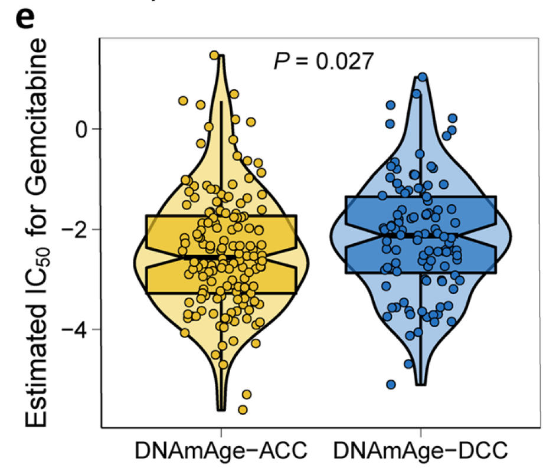

出自https://clinicalepigeneticsjournal.biomedcentral.com/articles/10.1186/s13148-020-0822-y

Fig. 1 Correlations between DNAm age and chronological age and other molecular characteristics of DNAm age groups. c DNAmAge-ACC group presented with significantly higher HPVpca scores than DNAmAge-DEC group and was inferred to be much more sensitive to two commonly used chemotherapy drugs, i.e. paclitaxel and gemcitabine, as shown in (d) and (e), respectively. The test for association between paired samples used Pearson’s correlation coefficient. Two-tailed statistical P values were calculated by a two-sample Mann-Whitney test or Student’s t test when appropriate

# 应用场景

对比两组或多组数据，原始数据、统计量（boxplot）、统计推断（violin plot, 概率密度）画一起。

类似于FigureYa68friends，一半violin、box、一半原始数据。

为什么这样画？原理可参考这篇https://mp.weixin.qq.com/s/kd-WbPXPrg6K2RFNydK-mQ。

# 环境设置

使用国内镜像安装包

```r
options("repos"= c(CRAN="https://mirrors.tuna.tsinghua.edu.cn/CRAN/"))
options(BioC_mirror="http://mirrors.ustc.edu.cn/bioc/")
```

加载包

```r
library(ggplot2)
library(ggpubr)
Sys.setenv(LANGUAGE = "en") #显示英文报错信息
options(stringsAsFactors = FALSE) #禁止chr转成factor
```

# 两组比较，原图复现

## 输入文件

```r
tmp <- read.csv("easy_input.csv", row.names = NULL, check.names = F, header = T, stringsAsFactors = F)
head(tmp)
```

```
##    est.ic50     DNAmAge
## 1 -3.449801 DNAmAge-ACC
## 2 -1.840905 DNAmAge-DCC
## 3 -3.040064 DNAmAge-ACC
## 4 -3.454262 DNAmAge-DCC
## 5 -2.741668 DNAmAge-ACC
## 6 -2.937070 DNAmAge-ACC
```

```r
table(tmp$DNAmAge)
```

```
##
## DNAmAge-ACC DNAmAge-DCC
##         148         104
```

## 非参检验

```r
p <- wilcox.test(tmp[which(tmp$DNAmAge == "DNAmAge-ACC"),"est.ic50"],tmp[which(tmp$DNAmAge == "DNAmAge-DCC"),"est.ic50"])$p.value
```

## 开始画图

用ggplot2画图

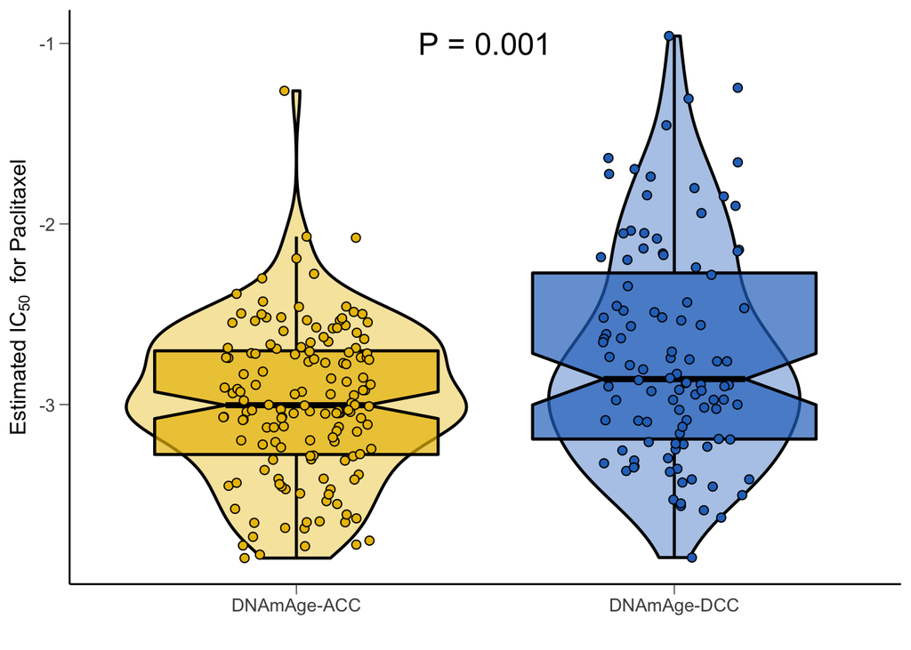

```r
# 设置颜色
jco <- c("#2874C5","#EABF00")

ggplot(data = tmp,aes(x = DNAmAge, y = est.ic50, fill = DNAmAge))+
  scale_fill_manual(values = jco[2:1]) +
  geom_violin(alpha=0.4, position = position_dodge(width = .75),
              size=0.8, color="black") + # 边框线黑色
  geom_boxplot(notch = TRUE, outlier.size = -1,
               color="black", lwd=0.8, alpha = 0.7)+ # 背景色透明化
  geom_point(shape = 21, size=2,
             position = position_jitterdodge(),
             color="black", alpha=1)+ # 边框线黑色
  theme_classic() +
  ylab(expression("Estimated IC"[50]~" for Paclitaxel")) +
  xlab("")  +
  annotate(geom="text", cex=6,
           x=1.5, y=-1, # 根据自己的数据调节p value的位置
           label=paste0("P ", ifelse(p<0.001, "< 0.001", paste0("= ",round(p,3)))), # 添加P值
           color="black") +
  theme(#panel.border = element_rect(colour = "black", fill=NA, size=0.2), # 原图有框
        axis.ticks = element_line(size=0.2,color="black"),
        axis.ticks.length = unit(0.2,"cm"),
        legend.position = "none",
        axis.title = element_text(size = 12),
        axis.text = element_text(size = 10))
```

```r
# 保存图像
ggsave("boxViolin.pdf", width = 4.5, height = 4)
```

# 多组比较

## 输入文件

```r
tmp <- read.csv("easy_input_multi.csv", row.names = NULL, check.names = F, header = T, stringsAsFactors = F)
head(tmp)
```

```
##   Enrichscore TGFBcluster
## 1   0.1261347   Pink-TGFB
## 2   0.3522893   Pink-TGFB
## 3   0.1158100   Pink-TGFB
## 4   0.1678759   Pink-TGFB
## 5   0.2079235   Pink-TGFB
## 6   0.2611214   Pink-TGFB
```

```r
table(tmp$TGFBcluster)
```

```
##
## Blue-TGFB Grey-TGFB Pink-TGFB  Red-TGFB
##        19        59        87        28
```

## 组间对比及画图

用ggpubr的stat_compare_means做kruskal.test

用ggplot2画图

```
## notch went outside hinges. Try setting notch=FALSE.
```

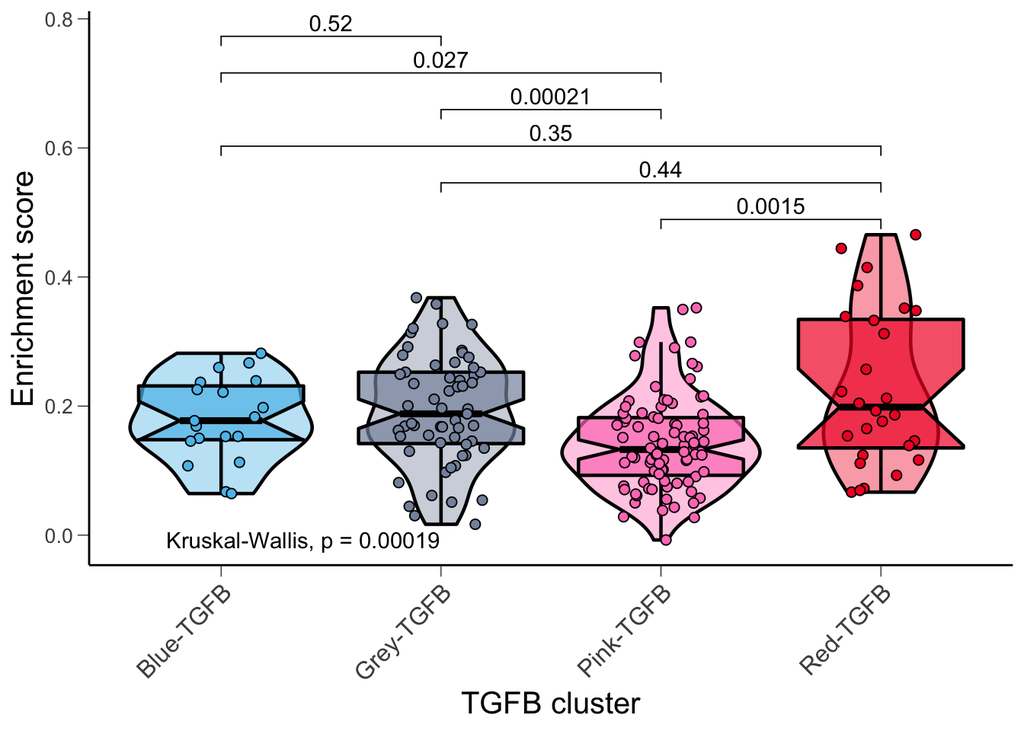

```r
# 设置组间对比，排列组合
my_comparisons <- list( c("Red-TGFB", "Pink-TGFB"),
                        c("Red-TGFB", "Grey-TGFB"),
                        c("Red-TGFB", "Blue-TGFB"),
                        c("Pink-TGFB","Grey-TGFB"),
                        c("Pink-TGFB","Blue-TGFB"),
                        c("Grey-TGFB","Blue-TGFB"))

#set color
blue   <- "#5bc0eb"
grey   <- "#8693ab"
darkred   <- "#F2042C"
lightred  <- "#FF7FBF"

ggplot(data = tmp,aes(x = TGFBcluster, #分组列名
                      y = Enrichscore, #连续变量列名
                      fill = TGFBcluster))+ #按分组填充颜色
  scale_fill_manual(values = c(blue, grey, lightred, darkred)) + #用自定义颜色填充
  geom_violin(alpha = 0.4, position = position_dodge(width = .75),
              size = 0.8, color="black") +
  geom_boxplot(notch = TRUE, outlier.size = -1,
               color="black", lwd=0.8, alpha = 0.7) +
  geom_point(shape = 21, size=2, # 点的性状和大小
             position = position_jitterdodge(), # 让点散开
             color="black", alpha = 1) +
  theme_classic() +
  ylab("Enrichment score") +
  xlab("TGFB cluster") +
  theme(axis.text.x = element_text(angle = 45, hjust = 1, size = 12),
        #panel.border = element_rect(colour = "black", fill=NA, size=0.2),
        axis.ticks = element_line(size=0.2, color="black"),
        axis.ticks.length = unit(0.2, "cm"),
        legend.position = "none",
        axis.title = element_text(size = 15),
        axis.text = element_text(size = 10)) +

  # 如果不要组间比较就注释掉下面这行
  stat_compare_means(comparisons = my_comparisons) +
  stat_compare_means(method = "kruskal.test", label.y = min(tmp$Enrichscore))
```

```r
p
```

```
## [1] 0.001196803
```

```r
ggsave("boxViolin_multipleGroups.pdf", width = 6, height = 6)
```

```
## notch went outside hinges. Try setting notch=FALSE.
```